# Risk Factor Analysis

## Outcome Variable

**Outcome Variable:** wast_rec90d

## Predictor Variables

**Intervention Variable:** nchldlt5

**Adjustment Set:**

- arm
- W_mage
- meducyrs
- feducyrs
- hhwealth_quart
- hfoodsec
- W_mhtcm
- W_mwtkg
- W_mbmi
- W_nrooms
- W_parity
- impfloor
- impsan
- safeh20
- delta_W_mage
- delta_meducyrs
- delta_feducyrs
- delta_hhwealth_quart
- delta_hfoodsec
- delta_W_mhtcm
- delta_W_mwtkg
- delta_W_mbmi
- delta_W_nrooms
- delta_W_parity
- delta_impfloor
- delta_impsan
- delta_safeh20

## Stratifying Variables

The analysis was stratified on these variable(s):

- agecat
- studyid
- country

## Data Summary

| agecat | studyid | country | nchldlt5 | wast_rec90d | n_cell | n |
| --- | --- | --- | --- | --- | --- | --- |
| 0-24 months | iLiNS-Zinc | BURKINA FASO | 1 | 0 | 241 | 787 |
| 0-24 months | iLiNS-Zinc | BURKINA FASO | 1 | 1 | 10 | 787 |
| 0-24 months | iLiNS-Zinc | BURKINA FASO | 2+ | 0 | 512 | 787 |
| 0-24 months | iLiNS-Zinc | BURKINA FASO | 2+ | 1 | 24 | 787 |
| 0-24 months | IRC | INDIA | 1 | 0 | 39 | 395 |
| 0-24 months | IRC | INDIA | 1 | 1 | 56 | 395 |
| 0-24 months | IRC | INDIA | 2+ | 0 | 123 | 395 |
| 0-24 months | IRC | INDIA | 2+ | 1 | 177 | 395 |
| 0-24 months | JiVitA-3 | BANGLADESH | 1 | 0 | 2739 | 7562 |
| 0-24 months | JiVitA-3 | BANGLADESH | 1 | 1 | 2148 | 7562 |
| 0-24 months | JiVitA-3 | BANGLADESH | 2+ | 0 | 1629 | 7562 |
| 0-24 months | JiVitA-3 | BANGLADESH | 2+ | 1 | 1046 | 7562 |
| 0-24 months | LCNI-5 | MALAWI | 1 | 0 | 25 | 78 |
| 0-24 months | LCNI-5 | MALAWI | 1 | 1 | 6 | 78 |
| 0-24 months | LCNI-5 | MALAWI | 2+ | 0 | 40 | 78 |
| 0-24 months | LCNI-5 | MALAWI | 2+ | 1 | 7 | 78 |
| 0-24 months | NIH-Crypto | BANGLADESH | 1 | 0 | 73 | 310 |
| 0-24 months | NIH-Crypto | BANGLADESH | 1 | 1 | 136 | 310 |
| 0-24 months | NIH-Crypto | BANGLADESH | 2+ | 0 | 44 | 310 |
| 0-24 months | NIH-Crypto | BANGLADESH | 2+ | 1 | 57 | 310 |
| 0-24 months | PROVIDE | BANGLADESH | 1 | 0 | 87 | 308 |
| 0-24 months | PROVIDE | BANGLADESH | 1 | 1 | 138 | 308 |
| 0-24 months | PROVIDE | BANGLADESH | 2+ | 0 | 42 | 308 |
| 0-24 months | PROVIDE | BANGLADESH | 2+ | 1 | 41 | 308 |
| 0-24 months | TanzaniaChild2 | TANZANIA, UNITED REPUBLIC OF | 1 | 0 | 186 | 711 |
| 0-24 months | TanzaniaChild2 | TANZANIA, UNITED REPUBLIC OF | 1 | 1 | 315 | 711 |
| 0-24 months | TanzaniaChild2 | TANZANIA, UNITED REPUBLIC OF | 2+ | 0 | 80 | 711 |
| 0-24 months | TanzaniaChild2 | TANZANIA, UNITED REPUBLIC OF | 2+ | 1 | 130 | 711 |
| 0-6 months | IRC | INDIA | 1 | 0 | 20 | 240 |
| 0-6 months | IRC | INDIA | 1 | 1 | 37 | 240 |
| 0-6 months | IRC | INDIA | 2+ | 0 | 67 | 240 |
| 0-6 months | IRC | INDIA | 2+ | 1 | 116 | 240 |
| 0-6 months | JiVitA-3 | BANGLADESH | 1 | 0 | 952 | 4730 |
| 0-6 months | JiVitA-3 | BANGLADESH | 1 | 1 | 2148 | 4730 |
| 0-6 months | JiVitA-3 | BANGLADESH | 2+ | 0 | 584 | 4730 |
| 0-6 months | JiVitA-3 | BANGLADESH | 2+ | 1 | 1046 | 4730 |
| 0-6 months | LCNI-5 | MALAWI | 1 | 0 | 1 | 4 |
| 0-6 months | LCNI-5 | MALAWI | 1 | 1 | 0 | 4 |
| 0-6 months | LCNI-5 | MALAWI | 2+ | 0 | 3 | 4 |
| 0-6 months | LCNI-5 | MALAWI | 2+ | 1 | 0 | 4 |
| 0-6 months | NIH-Crypto | BANGLADESH | 1 | 0 | 14 | 197 |
| 0-6 months | NIH-Crypto | BANGLADESH | 1 | 1 | 124 | 197 |
| 0-6 months | NIH-Crypto | BANGLADESH | 2+ | 0 | 7 | 197 |
| 0-6 months | NIH-Crypto | BANGLADESH | 2+ | 1 | 52 | 197 |
| 0-6 months | PROVIDE | BANGLADESH | 1 | 0 | 25 | 185 |
| 0-6 months | PROVIDE | BANGLADESH | 1 | 1 | 115 | 185 |
| 0-6 months | PROVIDE | BANGLADESH | 2+ | 0 | 15 | 185 |
| 0-6 months | PROVIDE | BANGLADESH | 2+ | 1 | 30 | 185 |
| 0-6 months | TanzaniaChild2 | TANZANIA, UNITED REPUBLIC OF | 1 | 0 | 66 | 339 |
| 0-6 months | TanzaniaChild2 | TANZANIA, UNITED REPUBLIC OF | 1 | 1 | 170 | 339 |
| 0-6 months | TanzaniaChild2 | TANZANIA, UNITED REPUBLIC OF | 2+ | 0 | 35 | 339 |
| 0-6 months | TanzaniaChild2 | TANZANIA, UNITED REPUBLIC OF | 2+ | 1 | 68 | 339 |
| 6-24 months | iLiNS-Zinc | BURKINA FASO | 1 | 0 | 241 | 787 |
| 6-24 months | iLiNS-Zinc | BURKINA FASO | 1 | 1 | 10 | 787 |
| 6-24 months | iLiNS-Zinc | BURKINA FASO | 2+ | 0 | 512 | 787 |
| 6-24 months | iLiNS-Zinc | BURKINA FASO | 2+ | 1 | 24 | 787 |
| 6-24 months | IRC | INDIA | 1 | 0 | 19 | 155 |
| 6-24 months | IRC | INDIA | 1 | 1 | 19 | 155 |
| 6-24 months | IRC | INDIA | 2+ | 0 | 56 | 155 |
| 6-24 months | IRC | INDIA | 2+ | 1 | 61 | 155 |
| 6-24 months | JiVitA-3 | BANGLADESH | 1 | 0 | 1787 | 2832 |
| 6-24 months | JiVitA-3 | BANGLADESH | 1 | 1 | 0 | 2832 |
| 6-24 months | JiVitA-3 | BANGLADESH | 2+ | 0 | 1045 | 2832 |
| 6-24 months | JiVitA-3 | BANGLADESH | 2+ | 1 | 0 | 2832 |
| 6-24 months | LCNI-5 | MALAWI | 1 | 0 | 24 | 74 |
| 6-24 months | LCNI-5 | MALAWI | 1 | 1 | 6 | 74 |
| 6-24 months | LCNI-5 | MALAWI | 2+ | 0 | 37 | 74 |
| 6-24 months | LCNI-5 | MALAWI | 2+ | 1 | 7 | 74 |
| 6-24 months | NIH-Crypto | BANGLADESH | 1 | 0 | 59 | 113 |
| 6-24 months | NIH-Crypto | BANGLADESH | 1 | 1 | 12 | 113 |
| 6-24 months | NIH-Crypto | BANGLADESH | 2+ | 0 | 37 | 113 |
| 6-24 months | NIH-Crypto | BANGLADESH | 2+ | 1 | 5 | 113 |
| 6-24 months | PROVIDE | BANGLADESH | 1 | 0 | 62 | 123 |
| 6-24 months | PROVIDE | BANGLADESH | 1 | 1 | 23 | 123 |
| 6-24 months | PROVIDE | BANGLADESH | 2+ | 0 | 27 | 123 |
| 6-24 months | PROVIDE | BANGLADESH | 2+ | 1 | 11 | 123 |
| 6-24 months | TanzaniaChild2 | TANZANIA, UNITED REPUBLIC OF | 1 | 0 | 120 | 372 |
| 6-24 months | TanzaniaChild2 | TANZANIA, UNITED REPUBLIC OF | 1 | 1 | 145 | 372 |
| 6-24 months | TanzaniaChild2 | TANZANIA, UNITED REPUBLIC OF | 2+ | 0 | 45 | 372 |
| 6-24 months | TanzaniaChild2 | TANZANIA, UNITED REPUBLIC OF | 2+ | 1 | 62 | 372 |

The following strata were considered:

- agecat: 0-24 months, studyid: iLiNS-Zinc, country: BURKINA FASO
- agecat: 0-24 months, studyid: IRC, country: INDIA
- agecat: 0-24 months, studyid: JiVitA-3, country: BANGLADESH
- agecat: 0-24 months, studyid: LCNI-5, country: MALAWI
- agecat: 0-24 months, studyid: NIH-Crypto, country: BANGLADESH
- agecat: 0-24 months, studyid: PROVIDE, country: BANGLADESH
- agecat: 0-24 months, studyid: TanzaniaChild2, country: TANZANIA, UNITED REPUBLIC OF
- agecat: 0-6 months, studyid: IRC, country: INDIA
- agecat: 0-6 months, studyid: JiVitA-3, country: BANGLADESH
- agecat: 0-6 months, studyid: LCNI-5, country: MALAWI
- agecat: 0-6 months, studyid: NIH-Crypto, country: BANGLADESH
- agecat: 0-6 months, studyid: PROVIDE, country: BANGLADESH
- agecat: 0-6 months, studyid: TanzaniaChild2, country: TANZANIA, UNITED REPUBLIC OF
- agecat: 6-24 months, studyid: iLiNS-Zinc, country: BURKINA FASO
- agecat: 6-24 months, studyid: IRC, country: INDIA
- agecat: 6-24 months, studyid: JiVitA-3, country: BANGLADESH
- agecat: 6-24 months, studyid: LCNI-5, country: MALAWI
- agecat: 6-24 months, studyid: NIH-Crypto, country: BANGLADESH
- agecat: 6-24 months, studyid: PROVIDE, country: BANGLADESH
- agecat: 6-24 months, studyid: TanzaniaChild2, country: TANZANIA, UNITED REPUBLIC OF

### Dropped Strata

Some strata were dropped due to rare outcomes:

- agecat: 0-6 months, studyid: LCNI-5, country: MALAWI
- agecat: 6-24 months, studyid: JiVitA-3, country: BANGLADESH

## Methods Detail

We’re interested in the causal parameters $E[Y_a]$ for all values of $a \in \mathcal{A}$. These parameters represent the mean outcome if, possibly contrary to fact, we intervened to set all units to have $A=a$. Under the randomization and positivity assumptions, these are identified by the statistical parameters $\psi_a=E_W[E_{Y|A,W}(Y|A=a,W)]$. In addition, we’re interested in the mean of $Y$, $E[Y]$ under no intervention (the observed mean). We will estimate these parameters by using SuperLearner to fit the relevant likelihood factors – $E_{Y|A,W}(Y|A=a,W)$ and $p(A=a|W)$, and then updating our likelihood fit using a joint TMLE.

For unadjusted analyses ($W=\{\}$), initial likelihoods were estimated using Lrnr_glm to estimate the simple $E(Y|A)$ and Lrnr_mean to estimate $p(A)$. For adjusted analyses, a small library containing Lrnr_glmnet, Lrnr_xgboost, and Lrnr_mean was used.

Having estimated these parameters, we will then use the delta method to estimate relative risks and attributable risks relative to a prespecified baseline level of $A$.

# Results Detail

## Results Plots

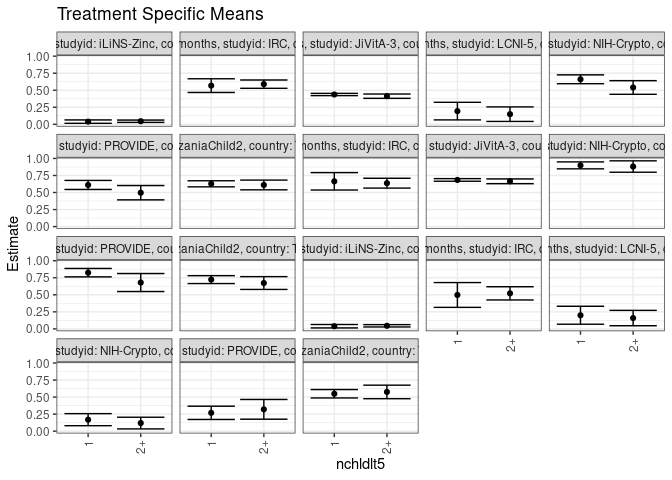

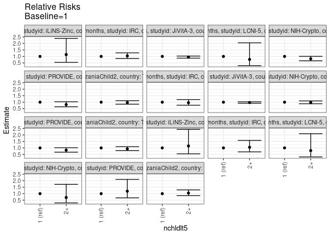

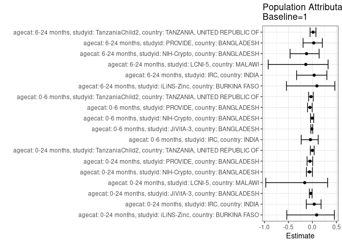

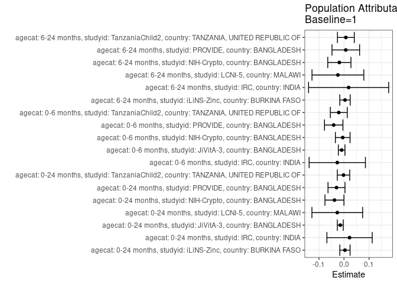

## Results Table

### Parameter: TSM

| agecat | studyid | country | intervention_level | baseline_level | estimate | ci_lower | ci_upper |
| --- | --- | --- | --- | --- | --- | --- | --- |
| 0-24 months | iLiNS-Zinc | BURKINA FASO | 1 | NA | 0.0394284 | 0.0145375 | 0.0643193 |
| 0-24 months | iLiNS-Zinc | BURKINA FASO | 2+ | NA | 0.0450565 | 0.0279268 | 0.0621861 |
| 0-24 months | IRC | INDIA | 1 | NA | 0.5676689 | 0.4673334 | 0.6680043 |
| 0-24 months | IRC | INDIA | 2+ | NA | 0.5891856 | 0.5283350 | 0.6500361 |
| 0-24 months | JiVitA-3 | BANGLADESH | 1 | NA | 0.4372353 | 0.4208028 | 0.4536679 |
| 0-24 months | JiVitA-3 | BANGLADESH | 2+ | NA | 0.4127621 | 0.3809888 | 0.4445353 |
| 0-24 months | LCNI-5 | MALAWI | 1 | NA | 0.1935484 | 0.0643859 | 0.3227109 |
| 0-24 months | LCNI-5 | MALAWI | 2+ | NA | 0.1489362 | 0.0421700 | 0.2557024 |
| 0-24 months | NIH-Crypto | BANGLADESH | 1 | NA | 0.6606788 | 0.5958145 | 0.7255430 |
| 0-24 months | NIH-Crypto | BANGLADESH | 2+ | NA | 0.5403065 | 0.4401328 | 0.6404802 |
| 0-24 months | PROVIDE | BANGLADESH | 1 | NA | 0.6110752 | 0.5446308 | 0.6775195 |
| 0-24 months | PROVIDE | BANGLADESH | 2+ | NA | 0.4972571 | 0.3920811 | 0.6024330 |
| 0-24 months | TanzaniaChild2 | TANZANIA, UNITED REPUBLIC OF | 1 | NA | 0.6278422 | 0.5833205 | 0.6723639 |
| 0-24 months | TanzaniaChild2 | TANZANIA, UNITED REPUBLIC OF | 2+ | NA | 0.6108211 | 0.5392575 | 0.6823847 |
| 0-6 months | IRC | INDIA | 1 | NA | 0.6643419 | 0.5364636 | 0.7922201 |
| 0-6 months | IRC | INDIA | 2+ | NA | 0.6370019 | 0.5650335 | 0.7089702 |
| 0-6 months | JiVitA-3 | BANGLADESH | 1 | NA | 0.6846361 | 0.6658037 | 0.7034686 |
| 0-6 months | JiVitA-3 | BANGLADESH | 2+ | NA | 0.6646829 | 0.6300718 | 0.6992940 |
| 0-6 months | NIH-Crypto | BANGLADESH | 1 | NA | 0.8985507 | 0.8475715 | 0.9495299 |
| 0-6 months | NIH-Crypto | BANGLADESH | 2+ | NA | 0.8813559 | 0.7977824 | 0.9649295 |
| 0-6 months | PROVIDE | BANGLADESH | 1 | NA | 0.8249029 | 0.7631676 | 0.8866382 |
| 0-6 months | PROVIDE | BANGLADESH | 2+ | NA | 0.6800542 | 0.5480362 | 0.8120722 |
| 0-6 months | TanzaniaChild2 | TANZANIA, UNITED REPUBLIC OF | 1 | NA | 0.7228953 | 0.6649189 | 0.7808716 |
| 0-6 months | TanzaniaChild2 | TANZANIA, UNITED REPUBLIC OF | 2+ | NA | 0.6729848 | 0.5789768 | 0.7669928 |
| 6-24 months | iLiNS-Zinc | BURKINA FASO | 1 | NA | 0.0391974 | 0.0139929 | 0.0644019 |
| 6-24 months | iLiNS-Zinc | BURKINA FASO | 2+ | NA | 0.0451313 | 0.0279404 | 0.0623222 |
| 6-24 months | IRC | INDIA | 1 | NA | 0.4976647 | 0.3155540 | 0.6797754 |
| 6-24 months | IRC | INDIA | 2+ | NA | 0.5213542 | 0.4241352 | 0.6185732 |
| 6-24 months | LCNI-5 | MALAWI | 1 | NA | 0.2000000 | 0.0680734 | 0.3319266 |
| 6-24 months | LCNI-5 | MALAWI | 2+ | NA | 0.1590909 | 0.0462498 | 0.2719320 |
| 6-24 months | NIH-Crypto | BANGLADESH | 1 | NA | 0.1690141 | 0.0805585 | 0.2574696 |
| 6-24 months | NIH-Crypto | BANGLADESH | 2+ | NA | 0.1190476 | 0.0331409 | 0.2049543 |
| 6-24 months | PROVIDE | BANGLADESH | 1 | NA | 0.2692213 | 0.1718444 | 0.3665981 |
| 6-24 months | PROVIDE | BANGLADESH | 2+ | NA | 0.3205460 | 0.1757270 | 0.4653650 |
| 6-24 months | TanzaniaChild2 | TANZANIA, UNITED REPUBLIC OF | 1 | NA | 0.5490328 | 0.4871893 | 0.6108763 |
| 6-24 months | TanzaniaChild2 | TANZANIA, UNITED REPUBLIC OF | 2+ | NA | 0.5757169 | 0.4762249 | 0.6752090 |

### Parameter: E(Y)

| agecat | studyid | country | intervention_level | baseline_level | estimate | ci_lower | ci_upper |
| --- | --- | --- | --- | --- | --- | --- | --- |
| 0-24 months | iLiNS-Zinc | BURKINA FASO | NA | NA | 0.0432020 | 0.0290622 | 0.0573419 |
| 0-24 months | IRC | INDIA | NA | NA | 0.5898734 | 0.5376978 | 0.6420491 |
| 0-24 months | JiVitA-3 | BANGLADESH | NA | NA | 0.4223750 | 0.4112475 | 0.4335026 |
| 0-24 months | LCNI-5 | MALAWI | NA | NA | 0.1666667 | 0.0842830 | 0.2490503 |
| 0-24 months | NIH-Crypto | BANGLADESH | NA | NA | 0.6225806 | 0.5684562 | 0.6767051 |
| 0-24 months | PROVIDE | BANGLADESH | NA | NA | 0.5811688 | 0.5245443 | 0.6377934 |
| 0-24 months | TanzaniaChild2 | TANZANIA, UNITED REPUBLIC OF | NA | NA | 0.6258790 | 0.5881498 | 0.6636083 |
| 0-6 months | IRC | INDIA | NA | NA | 0.6375000 | 0.5751450 | 0.6998550 |
| 0-6 months | JiVitA-3 | BANGLADESH | NA | NA | 0.6752643 | 0.6619190 | 0.6886095 |
| 0-6 months | NIH-Crypto | BANGLADESH | NA | NA | 0.8934010 | 0.8497799 | 0.9370221 |
| 0-6 months | PROVIDE | BANGLADESH | NA | NA | 0.7837838 | 0.7252863 | 0.8422812 |
| 0-6 months | TanzaniaChild2 | TANZANIA, UNITED REPUBLIC OF | NA | NA | 0.7020649 | 0.6526590 | 0.7514708 |
| 6-24 months | iLiNS-Zinc | BURKINA FASO | NA | NA | 0.0432020 | 0.0290622 | 0.0573419 |
| 6-24 months | IRC | INDIA | NA | NA | 0.5161290 | 0.4322562 | 0.6000019 |
| 6-24 months | LCNI-5 | MALAWI | NA | NA | 0.1756757 | 0.0897916 | 0.2615597 |
| 6-24 months | NIH-Crypto | BANGLADESH | NA | NA | 0.1504425 | 0.0860251 | 0.2148599 |
| 6-24 months | PROVIDE | BANGLADESH | NA | NA | 0.2764228 | 0.1950773 | 0.3577682 |
| 6-24 months | TanzaniaChild2 | TANZANIA, UNITED REPUBLIC OF | NA | NA | 0.5564516 | 0.5041613 | 0.6087419 |

### Parameter: RR

| agecat | studyid | country | intervention_level | baseline_level | estimate | ci_lower | ci_upper |
| --- | --- | --- | --- | --- | --- | --- | --- |
| 0-24 months | iLiNS-Zinc | BURKINA FASO | 1 | 1 | 1.0000000 | 1.0000000 | 1.000000 |
| 0-24 months | iLiNS-Zinc | BURKINA FASO | 2+ | 1 | 1.1427428 | 0.5479844 | 2.383026 |
| 0-24 months | IRC | INDIA | 1 | 1 | 1.0000000 | 1.0000000 | 1.000000 |
| 0-24 months | IRC | INDIA | 2+ | 1 | 1.0379036 | 0.8442791 | 1.275933 |
| 0-24 months | JiVitA-3 | BANGLADESH | 1 | 1 | 1.0000000 | 1.0000000 | 1.000000 |
| 0-24 months | JiVitA-3 | BANGLADESH | 2+ | 1 | 0.9440272 | 0.8667605 | 1.028182 |
| 0-24 months | LCNI-5 | MALAWI | 1 | 1 | 1.0000000 | 1.0000000 | 1.000000 |
| 0-24 months | LCNI-5 | MALAWI | 2+ | 1 | 0.7695035 | 0.2889550 | 2.049231 |
| 0-24 months | NIH-Crypto | BANGLADESH | 1 | 1 | 1.0000000 | 1.0000000 | 1.000000 |
| 0-24 months | NIH-Crypto | BANGLADESH | 2+ | 1 | 0.8178052 | 0.6628428 | 1.008995 |
| 0-24 months | PROVIDE | BANGLADESH | 1 | 1 | 1.0000000 | 1.0000000 | 1.000000 |
| 0-24 months | PROVIDE | BANGLADESH | 2+ | 1 | 0.8137412 | 0.6413976 | 1.032394 |
| 0-24 months | TanzaniaChild2 | TANZANIA, UNITED REPUBLIC OF | 1 | 1 | 1.0000000 | 1.0000000 | 1.000000 |
| 0-24 months | TanzaniaChild2 | TANZANIA, UNITED REPUBLIC OF | 2+ | 1 | 0.9728895 | 0.8482744 | 1.115811 |
| 0-6 months | IRC | INDIA | 1 | 1 | 1.0000000 | 1.0000000 | 1.000000 |
| 0-6 months | IRC | INDIA | 2+ | 1 | 0.9588465 | 0.7668124 | 1.198972 |
| 0-6 months | JiVitA-3 | BANGLADESH | 1 | 1 | 1.0000000 | 1.0000000 | 1.000000 |
| 0-6 months | JiVitA-3 | BANGLADESH | 2+ | 1 | 0.9708558 | 0.9155589 | 1.029492 |
| 0-6 months | NIH-Crypto | BANGLADESH | 1 | 1 | 1.0000000 | 1.0000000 | 1.000000 |
| 0-6 months | NIH-Crypto | BANGLADESH | 2+ | 1 | 0.9808639 | 0.8782515 | 1.095465 |
| 0-6 months | PROVIDE | BANGLADESH | 1 | 1 | 1.0000000 | 1.0000000 | 1.000000 |
| 0-6 months | PROVIDE | BANGLADESH | 2+ | 1 | 0.8244052 | 0.6709372 | 1.012977 |
| 0-6 months | TanzaniaChild2 | TANZANIA, UNITED REPUBLIC OF | 1 | 1 | 1.0000000 | 1.0000000 | 1.000000 |
| 0-6 months | TanzaniaChild2 | TANZANIA, UNITED REPUBLIC OF | 2+ | 1 | 0.9309575 | 0.7919789 | 1.094325 |
| 6-24 months | iLiNS-Zinc | BURKINA FASO | 1 | 1 | 1.0000000 | 1.0000000 | 1.000000 |
| 6-24 months | iLiNS-Zinc | BURKINA FASO | 2+ | 1 | 1.1513848 | 0.5463109 | 2.426616 |
| 6-24 months | IRC | INDIA | 1 | 1 | 1.0000000 | 1.0000000 | 1.000000 |
| 6-24 months | IRC | INDIA | 2+ | 1 | 1.0476013 | 0.6943706 | 1.580523 |
| 6-24 months | LCNI-5 | MALAWI | 1 | 1 | 1.0000000 | 1.0000000 | 1.000000 |
| 6-24 months | LCNI-5 | MALAWI | 2+ | 1 | 0.7954545 | 0.3019242 | 2.095718 |
| 6-24 months | NIH-Crypto | BANGLADESH | 1 | 1 | 1.0000000 | 1.0000000 | 1.000000 |
| 6-24 months | NIH-Crypto | BANGLADESH | 2+ | 1 | 0.7043651 | 0.2888063 | 1.717865 |
| 6-24 months | PROVIDE | BANGLADESH | 1 | 1 | 1.0000000 | 1.0000000 | 1.000000 |
| 6-24 months | PROVIDE | BANGLADESH | 2+ | 1 | 1.1906413 | 0.6750198 | 2.100126 |
| 6-24 months | TanzaniaChild2 | TANZANIA, UNITED REPUBLIC OF | 1 | 1 | 1.0000000 | 1.0000000 | 1.000000 |
| 6-24 months | TanzaniaChild2 | TANZANIA, UNITED REPUBLIC OF | 2+ | 1 | 1.0486021 | 0.8526703 | 1.289556 |

### Parameter: PAR

| agecat | studyid | country | intervention_level | baseline_level | estimate | ci_lower | ci_upper |
| --- | --- | --- | --- | --- | --- | --- | --- |
| 0-24 months | iLiNS-Zinc | BURKINA FASO | 1 | NA | 0.0037737 | -0.0166733 | 0.0242206 |
| 0-24 months | IRC | INDIA | 1 | NA | 0.0222046 | -0.0683033 | 0.1127124 |
| 0-24 months | JiVitA-3 | BANGLADESH | 1 | NA | -0.0148603 | -0.0266817 | -0.0030389 |
| 0-24 months | LCNI-5 | MALAWI | 1 | NA | -0.0268817 | -0.1281436 | 0.0743802 |
| 0-24 months | NIH-Crypto | BANGLADESH | 1 | NA | -0.0380981 | -0.0760641 | -0.0001322 |
| 0-24 months | PROVIDE | BANGLADESH | 1 | NA | -0.0299063 | -0.0638382 | 0.0040256 |
| 0-24 months | TanzaniaChild2 | TANZANIA, UNITED REPUBLIC OF | 1 | NA | -0.0019631 | -0.0267560 | 0.0228298 |
| 0-6 months | IRC | INDIA | 1 | NA | -0.0268419 | -0.1392204 | 0.0855367 |
| 0-6 months | JiVitA-3 | BANGLADESH | 1 | NA | -0.0093718 | -0.0226340 | 0.0038903 |
| 0-6 months | NIH-Crypto | BANGLADESH | 1 | NA | -0.0051497 | -0.0344911 | 0.0241917 |
| 0-6 months | PROVIDE | BANGLADESH | 1 | NA | -0.0411191 | -0.0779024 | -0.0043358 |
| 0-6 months | TanzaniaChild2 | TANZANIA, UNITED REPUBLIC OF | 1 | NA | -0.0208304 | -0.0546539 | 0.0129932 |
| 6-24 months | iLiNS-Zinc | BURKINA FASO | 1 | NA | 0.0040046 | -0.0167298 | 0.0247391 |
| 6-24 months | IRC | INDIA | 1 | NA | 0.0184643 | -0.1414835 | 0.1784122 |
| 6-24 months | LCNI-5 | MALAWI | 1 | NA | -0.0243243 | -0.1278155 | 0.0791669 |
| 6-24 months | NIH-Crypto | BANGLADESH | 1 | NA | -0.0185716 | -0.0649036 | 0.0277604 |
| 6-24 months | PROVIDE | BANGLADESH | 1 | NA | 0.0072015 | -0.0479254 | 0.0623284 |
| 6-24 months | TanzaniaChild2 | TANZANIA, UNITED REPUBLIC OF | 1 | NA | 0.0074188 | -0.0261638 | 0.0410014 |

### Parameter: PAF

| agecat | studyid | country | intervention_level | baseline_level | estimate | ci_lower | ci_upper |
| --- | --- | --- | --- | --- | --- | --- | --- |
| 0-24 months | iLiNS-Zinc | BURKINA FASO | 1 | NA | 0.0873492 | -0.5345095 | 0.4572001 |
| 0-24 months | IRC | INDIA | 1 | NA | 0.0376429 | -0.1283937 | 0.1792482 |
| 0-24 months | JiVitA-3 | BANGLADESH | 1 | NA | -0.0351827 | -0.0635448 | -0.0075770 |
| 0-24 months | LCNI-5 | MALAWI | 1 | NA | -0.1612903 | -0.9712387 | 0.3158641 |
| 0-24 months | NIH-Crypto | BANGLADESH | 1 | NA | -0.0611939 | -0.1244301 | -0.0015140 |
| 0-24 months | PROVIDE | BANGLADESH | 1 | NA | -0.0514589 | -0.1116445 | 0.0054682 |
| 0-24 months | TanzaniaChild2 | TANZANIA, UNITED REPUBLIC OF | 1 | NA | -0.0031366 | -0.0435484 | 0.0357102 |
| 0-6 months | IRC | INDIA | 1 | NA | -0.0421049 | -0.2342862 | 0.1201533 |
| 0-6 months | JiVitA-3 | BANGLADESH | 1 | NA | -0.0138788 | -0.0337116 | 0.0055735 |
| 0-6 months | NIH-Crypto | BANGLADESH | 1 | NA | -0.0057642 | -0.0391686 | 0.0265665 |
| 0-6 months | PROVIDE | BANGLADESH | 1 | NA | -0.0524623 | -0.1015311 | -0.0055793 |
| 0-6 months | TanzaniaChild2 | TANZANIA, UNITED REPUBLIC OF | 1 | NA | -0.0296701 | -0.0791857 | 0.0175736 |
| 6-24 months | iLiNS-Zinc | BURKINA FASO | 1 | NA | 0.0926957 | -0.5419722 | 0.4661375 |
| 6-24 months | IRC | INDIA | 1 | NA | 0.0357747 | -0.3299559 | 0.3009313 |
| 6-24 months | LCNI-5 | MALAWI | 1 | NA | -0.1384615 | -0.9209109 | 0.3252708 |
| 6-24 months | NIH-Crypto | BANGLADESH | 1 | NA | -0.1234466 | -0.4658052 | 0.1389496 |
| 6-24 months | PROVIDE | BANGLADESH | 1 | NA | 0.0260524 | -0.1952618 | 0.2063882 |
| 6-24 months | TanzaniaChild2 | TANZANIA, UNITED REPUBLIC OF | 1 | NA | 0.0133324 | -0.0489025 | 0.0718746 |